# Multivariate smoothing, model selection

### Recap

- How GAMs work
- How to include detection info
- Simple spatial-only models
- How to check those models

## Univariate models are fun, but...

### Ecology is not univariate

- Many variables affect distribution
- Want to model the **right** ones
- Select between possible models
  - Smooth term selection
  - Response distribution
- Large literature on model selection

## Models with multiple smooths

### Adding smooths

- Already know that `+` is our friend
- Add everything then remove smooth terms?

```r
dsm_all <- dsm(count~s(x, y) +
                        s(Depth) +
                        s(DistToCAS) +
                        s(SST) +
                        s(EKE) +
                        s(NPP),
                  ddf.obj=df_hr,
                  segment.data=segs, observation.data=obs,
                  family=tw())
```

## Now we have a huge model, what do we do?

### Smooth term selection

- Classically, two main approaches
- Both have problems
- Usually use \( p \)-values

**Stepwise selection** - path dependence

**All possible subsets** - computationally expensive (fishing?)

### p-values

- \( p \)-values can calculate
- Test for zero effect of a smooth
- They are **approximate** for GAMs (but useful)
- Reported in `summary`

### p-values example

```r
summary(dsm_all)
```

```
Family: Tweedie(p=1.25)
Link function: log

Formula:
count ~ s(x, y) + s(Depth) + s(DistToCAS) + s(SST) + s(EKE) +
    s(NPP) + offset(off.set)

Parametric coefficients:
            Estimate Std. Error t value Pr(>|t|)
(Intercept) -20.6369     0.2752     -75   <2e-16 ***
---
Signif. codes:  0 '***' 0.001 '**' 0.01 '*' 0.05 '.' 0.1 ' ' 1

Approximate significance of smooth terms:
               edf Ref.df     F p-value
s(x,y)       5.236  7.169 1.233  0.2928
s(Depth)     3.568  4.439 6.640 1.6e-05 ***
s(DistToCAS) 1.000  1.000 1.503  0.2205
s(SST)       5.927  6.987 2.067  0.0407 *
s(EKE)       1.763  2.225 2.577  0.0696 .
s(NPP)       2.393  3.068 0.855  0.4680
---
Signif. codes:  0 '***' 0.001 '**' 0.01 '*' 0.05 '.' 0.1 ' ' 1

R-sq.(adj) =  0.224   Deviance explained = 44.8%
-REML = 368.97  Scale est. = 3.9334    n = 949
```

### Shrinkage or extra penalties

- Use penalty to remove terms during fitting
- Two methods
- Basis `s(..., bs="ts")` - thin plate splines with shrinkage
  - nullspace should be shrunk less than the wiggly part
- `dsm(..., select=TRUE)` - extra penalty
  - no assumption of how much to shrink the nullspace

### Shrinkage example

```r
dsm_ts_all <- dsm(count~s(x, y, bs="ts") +
                        s(Depth, bs="ts") +
                        s(DistToCAS, bs="ts") +
                        s(SST, bs="ts") +
                        s(EKE, bs="ts") +
                        s(NPP, bs="ts"),
                  ddf.obj=df_hr,
                  segment.data=segs, observation.data=obs,
                  family=tw())
```

### Shrinkage example

```r
summary(dsm_ts_all)
```

```
Family: Tweedie(p=1.277)
Link function: log

Formula:
count ~ s(x, y, bs = "ts") + s(Depth, bs = "ts") + s(DistToCAS,
    bs = "ts") + s(SST, bs = "ts") + s(EKE, bs = "ts") + s(NPP,
    bs = "ts") + offset(off.set)

Parametric coefficients:
            Estimate Std. Error t value Pr(>|t|)
(Intercept)  -20.260      0.234  -86.59   <2e-16 ***
---
Signif. codes:  0 '***' 0.001 '**' 0.01 '*' 0.05 '.' 0.1 ' ' 1

Approximate significance of smooth terms:
                   edf Ref.df     F  p-value
s(x,y)       1.888e+00     29 0.705 3.56e-06 ***
s(Depth)     3.679e+00      9 4.811 2.15e-10 ***
s(DistToCAS) 9.339e-05      9 0.000   0.6797
s(SST)       3.827e-01      9 0.063   0.2160
s(EKE)       8.196e-01      9 0.499   0.0178 *
s(NPP)       3.570e-04      9 0.000   0.8359
---
Signif. codes:  0 '***' 0.001 '**' 0.01 '*' 0.05 '.' 0.1 ' ' 1

R-sq.(adj) =   0.11   Deviance explained =   35%
-REML = 385.04  Scale est. = 4.5486    n = 949
```

### Extra penalty example

```r
dsm_sel <- dsm(count~s(x, y) +
                     s(Depth) +
                     s(DistToCAS) +
                     s(SST) +
                     s(EKE) +
                     s(NPP),
                  ddf.obj=df_hr,
                  segment.data=segs, observation.data=obs,
                  family=tw(), select=TRUE)
```

### Extra penalty example

```r
summary(dsm_sel)
```

```
Family: Tweedie(p=1.266)
Link function: log

Formula:
count ~ s(x, y) + s(Depth) + s(DistToCAS) + s(SST) + s(EKE) +
    s(NPP) + offset(off.set)

Parametric coefficients:
            Estimate Std. Error t value Pr(>|t|)
(Intercept) -20.4285     0.2454  -83.23   <2e-16 ***
---
Signif. codes:  0 '***' 0.001 '**' 0.01 '*' 0.05 '.' 0.1 ' ' 1

Approximate significance of smooth terms:
                   edf Ref.df     F  p-value
s(x,y)       7.694e+00     29 1.272 2.67e-07 ***
s(Depth)     3.645e+00      9 4.005 3.24e-10 ***
s(DistToCAS) 1.944e-05      9 0.000   0.7038
s(SST)       2.010e-04      9 0.000   0.8216
s(EKE)       1.417e+00      9 0.630   0.0127 *
s(NPP)       2.318e-04      9 0.000   0.5152
---
Signif. codes:  0 '***' 0.001 '**' 0.01 '*' 0.05 '.' 0.1 ' ' 1

R-sq.(adj) =   0.16   Deviance explained = 40.8%
-REML =    378  Scale est. = 4.2252    n = 949
```

### EDF comparison

```
             allterms select     ts
s(x,y)          5.236 7.6936 1.8875
s(Depth)        3.568 3.6449 3.6794
s(DistToCAS)    1.000 0.0000 0.0001
s(SST)          5.927 0.0002 0.3827
s(EKE)          1.763 1.4174 0.8196
s(NPP)          2.393 0.0002 0.0004
```

### Double penalty can be slow

- Lots of smoothing parameters to estimate

```r
length(dsm_ts_all$sp)
```

```
[1] 6
```

```r
length(dsm_sel$sp)
```

```
[1] 12
```

## Let's employ a mixture of these techniques

### How do we select smooth terms?

1. Look at EDF
   - Terms with EDF<1 may not be useful
   - These can usually be removed
2. Remove non-significant terms by \( p \)-value
   - Decide on a significance level and use that as a rule

(In some sense leaving “shrunk” terms in is more “consistent”, but can be computationally annoying)

## Example of selection

### Selecting smooth terms

```
Family: Tweedie(p=1.277)
Link function: log

Formula:
count ~ s(x, y, bs = "ts") + s(Depth, bs = "ts") + s(DistToCAS,
    bs = "ts") + s(SST, bs = "ts") + s(EKE, bs = "ts") + s(NPP,
    bs = "ts") + offset(off.set)

Parametric coefficients:
            Estimate Std. Error t value Pr(>|t|)
(Intercept)  -20.260      0.234  -86.59   <2e-16 ***
---
Signif. codes:  0 '***' 0.001 '**' 0.01 '*' 0.05 '.' 0.1 ' ' 1

Approximate significance of smooth terms:
                   edf Ref.df     F  p-value
s(x,y)       1.888e+00     29 0.705 3.56e-06 ***
s(Depth)     3.679e+00      9 4.811 2.15e-10 ***
s(DistToCAS) 9.339e-05      9 0.000   0.6797
s(SST)       3.827e-01      9 0.063   0.2160
s(EKE)       8.196e-01      9 0.499   0.0178 *
s(NPP)       3.570e-04      9 0.000   0.8359
---
Signif. codes:  0 '***' 0.001 '**' 0.01 '*' 0.05 '.' 0.1 ' ' 1

R-sq.(adj) =   0.11   Deviance explained =   35%
-REML = 385.04  Scale est. = 4.5486    n = 949
```

### Shrinkage in action

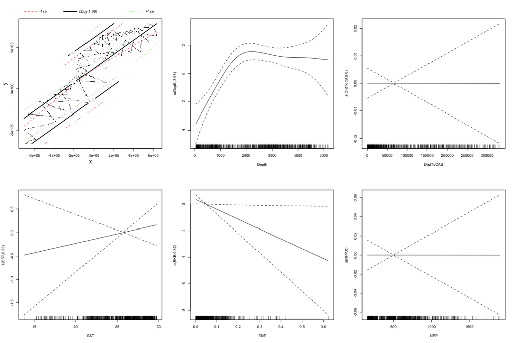

### Same model with no shrinkage

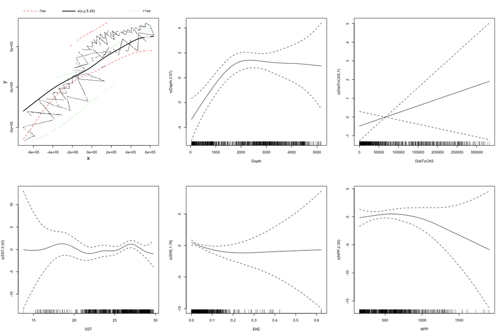

### Let's remove some smooth terms & refit

```r
dsm_all_tw_rm <- dsm(count~s(x, y, bs="ts") +
                        s(Depth, bs="ts") +
                        #s(DistToCAS, bs="ts") +
                        #s(SST, bs="ts") +
                        s(EKE, bs="ts"),#+
                        #s(NPP, bs="ts"),
                     ddf.obj=df_hr,
                     segment.data=segs,
                     observation.data=obs,
                     family=tw())
```

### What does that look like?

```
Family: Tweedie(p=1.279)
Link function: log

Formula:
count ~ s(x, y, bs = "ts") + s(Depth, bs = "ts") + s(EKE, bs = "ts") +
    offset(off.set)

Parametric coefficients:
            Estimate Std. Error t value Pr(>|t|)
(Intercept)  -20.258      0.234  -86.56   <2e-16 ***
---
Signif. codes:  0 '***' 0.001 '**' 0.01 '*' 0.05 '.' 0.1 ' ' 1

Approximate significance of smooth terms:
            edf Ref.df     F  p-value
s(x,y)   1.8969     29 0.707 1.76e-05 ***
s(Depth) 3.6949      9 5.024 1.08e-10 ***
s(EKE)   0.8106      9 0.470   0.0216 *
---
Signif. codes:  0 '***' 0.001 '**' 0.01 '*' 0.05 '.' 0.1 ' ' 1

R-sq.(adj) =  0.105   Deviance explained = 34.8%
-REML = 385.09  Scale est. = 4.5733    n = 949
```

### Removing EKE...

```
Family: Tweedie(p=1.268)
Link function: log

Formula:
count ~ s(x, y, bs = "ts") + s(Depth, bs = "ts") + offset(off.set)

Parametric coefficients:
            Estimate Std. Error t value Pr(>|t|)
(Intercept) -20.3088     0.2425  -83.75   <2e-16 ***
---
Signif. codes:  0 '***' 0.001 '**' 0.01 '*' 0.05 '.' 0.1 ' ' 1

Approximate significance of smooth terms:
           edf Ref.df     F  p-value
s(x,y)   6.443     29 1.322 4.75e-08 ***
s(Depth) 3.611      9 4.261 1.49e-10 ***
---
Signif. codes:  0 '***' 0.001 '**' 0.01 '*' 0.05 '.' 0.1 ' ' 1

R-sq.(adj) =  0.141   Deviance explained = 37.8%
-REML = 389.86  Scale est. = 4.3516    n = 949
```

### General strategy

For each response distribution and non-nested model structure:

1. Build a model with the smooths you want
2. Make sure that smooths are flexible enough (`k=...`)
3. Remove smooths that have been shrunk
4. Remove non-significant smooths

## Comparing models

### Comparing models

- Usually have >1 option
- How can we pick?
- Even if we have 1 model, is it any good?

### Nested vs. non-nested models

- Compare `~s(x)+s(depth)` with `~s(x)`
  - nested models
- What about `s(x) + s(y)` vs. `s(x, y)`
  - don't want to have all these in the model
  - not nested models

### Measures of "fit"

- Two listed in `summary`
  - Deviance explained
  - Adjusted \( R^2 \)
- Deviance is a generalisation of \( R^2 \)
- Highest likelihood value (*saturated* model) minus estimated model value
- (These are usually not very high for DSMs)

### AIC

- Can get AIC from our model
- Comparison of AIC fine (but not the end of the story)

```r
AIC(dsm_all)
```

```
[1] 1238.307
```

```r
AIC(dsm_ts_all)
```

```
[1] 1225.822
```

### A quick note about REML scores

- Use REML to select the smoothness
- Can also use the score to do model selection
- **BUT** only compare models with the same fixed effects
  - (i.e., same “linear terms” in the model)
- \( \Rightarrow \) **All terms** must be penalised
  - `bs="ts"` or `select=TRUE`

## Selecting between response distributions

### Goodness of fit tests

- Q-Q plots
- Closer to the line == better

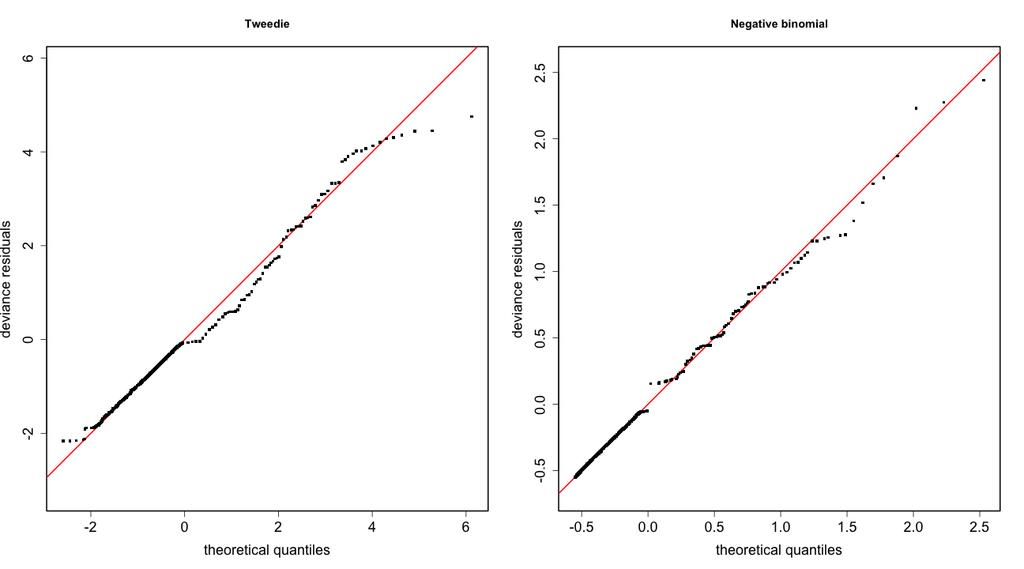

## Tobler's first law of geography

“Everything is related to everything else, but near things are more related than distant things”

Tobler (1970)

### Implications of Tobler's law

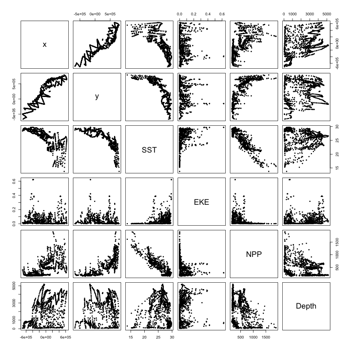

Covariates are not only correlated (linearly)…  
…they are also “concurve”

“How much can one smooth be approximated by one or more other smooths?”

### Concurvity (model/smooth)

```r
concurvity(dsm_all)
```

```
                 para    s(x,y)  s(Depth) s(DistToCAS)    s(SST)    s(EKE)
worst    2.539199e-23 0.9963493 0.9836597    0.9959057 0.9772853 0.7702479
observed 2.539199e-23 0.9213461 0.8275679    0.9883162 0.6951997 0.6615697
estimate 2.539199e-23 0.7580838 0.9272203    0.9642030 0.8978412 0.4906765
            s(NPP)
worst    0.9727752
observed 0.8258504
estimate 0.8694619
```

### Concurvity between smooths

```r
concurvity(dsm_all, full=FALSE)$estimate
```

```
                     para       s(x,y)     s(Depth) s(DistToCAS)
para         1.000000e+00 4.700364e-26 4.640330e-28 6.317431e-27
s(x,y)       8.687343e-24 1.000000e+00 9.067347e-01 9.568609e-01
s(Depth)     1.960563e-25 2.247389e-01 1.000000e+00 2.699392e-01
s(DistToCAS) 2.964353e-24 4.335154e-01 2.568123e-01 1.000000e+00
s(SST)       3.614289e-25 5.102860e-01 3.707617e-01 5.107111e-01
s(EKE)       1.283557e-24 1.220299e-01 1.527425e-01 1.205373e-01
s(NPP)       2.034284e-25 4.407590e-01 2.067464e-01 2.701934e-01
                   s(SST)       s(EKE)       s(NPP)
para         5.042066e-28 3.615073e-27 6.078290e-28
s(x,y)       7.205518e-01 3.201531e-01 6.821674e-01
s(Depth)     1.232244e-01 6.422005e-02 1.990567e-01
s(DistToCAS) 2.554027e-01 1.319306e-01 2.590227e-01
s(SST)       1.000000e+00 1.735256e-01 7.616800e-01
s(EKE)       2.410615e-01 1.000000e+00 2.787592e-01
s(NPP)       7.833972e-01 1.033109e-01 1.000000e+00
```

### Visualising concurvity between terms

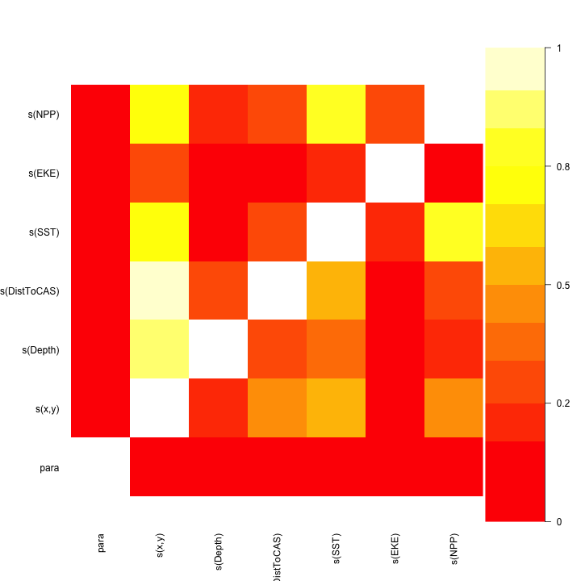

- Previous matrix output visualised
- High values (yellow) = BAD

## Path dependence

### Sensitivity

- General path dependency?
- What if there are highly concurve smooths?
- Is the model is sensitive to them?

### What can we do?

- Fit variations excluding smooths
  - Concurve terms that are excluded early on
- Appendix of Winiarski et al (2014) has an example

### Sensitivity example

- `s(Depth)` and `s(x, y)` are highly concurve (0.9067)
- Refit removing `Depth` first

```
# with depth
```

```
              edf Ref.df        F     p-value
s(x,y)   6.443109     29 1.321664 4.75402e-08
s(Depth) 3.611031      9 4.261217 1.48593e-10
```

```
# without depth
```

```
              edf Ref.df        F      p-value
s(x,y) 13.7776636     29 2.589135 1.161592e-12
s(EKE)  0.8448449      9 0.566980 1.050411e-02
s(NPP)  0.7994187      9 0.362814 3.231808e-02
```

### Comparison of spatial effects

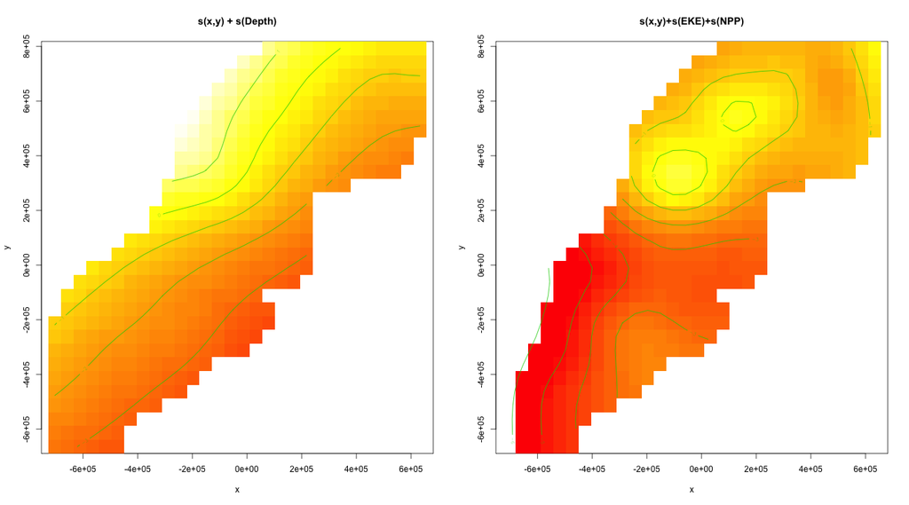

### Sensitivity example

- Refit removing `x` and `y`…

```
# without xy
```

```
              edf Ref.df        F      p-value
s(SST)   4.583260      9 3.244322 3.118815e-06
s(Depth) 3.973359      9 6.799043 4.125701e-14
```

```
# with xy
```

```
              edf Ref.df        F     p-value
s(x,y)   6.443109     29 1.321664 4.75402e-08
s(Depth) 3.611031      9 4.261217 1.48593e-10
```

### Comparison of depth smooths

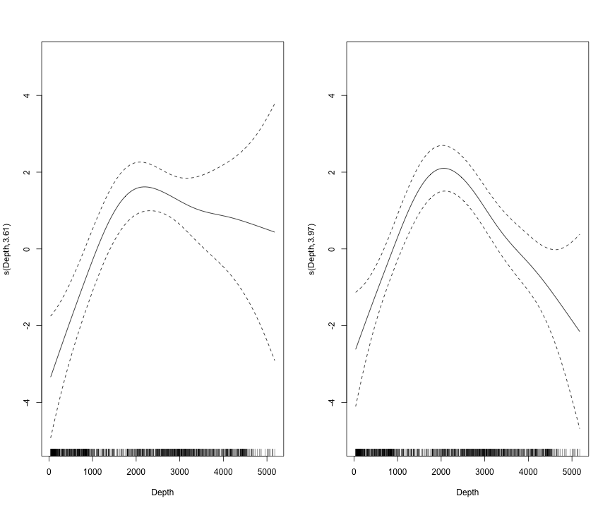

### Comparing those three models...

| Model | AIC | Deviance |
| --- | --- | --- |
| `s(x,y) + s(Depth)` | 1229.888 | 37.84 |
| `s(x,y)+s(EKE)+s(NPP)` | 1248.167 | 34.44 |
| `s(SST)+s(Depth)` | 1228.152 | 35.77 |

- “Full” model still explains most deviance
- No depth model requires spatial smooth to “mop up” extra variation
- We'll come back to this when we do prediction

## Recap

### Recap

- Adding smooths
- Removing smooths
  - \( p \)-values
  - shrinkage/extra penalties
- Comparing models
- Comparing response distributions
- Sensitivity